# Problem Statement - Plant Seedlings Image Classification using CNNs in Keras

## `Data Description:`

You are provided with a dataset of images of plant seedlings at various stages of grown. Each image has a filename that is its unique id. The dataset comprises 12 plant species. The goal of the project is to create a classifier capable of determining a plant's species from a photo.

## `Dataset:`

The dataset can be download from Olympus. The data file names are:

- images.npy
- Label.csv

## `Context:`

Can you differentiate a weed from a crop seedling? The ability to do so effectively can mean better crop yields and better stewardship of the environment. The Aarhus University Signal Processing group, in collaboration with University of Southern Denmark, has recently released a dataset containing images of unique plants belonging to 12 species at several growth stages

## `Objective:`

To implement the techniques learnt as a part of the course.

## `Learning Outcomes:`

- Pre-processing of image data.
- Visualization of images.
- Building CNN.
- Evaluate the Model.

The motive of the project is to make the learners capable to handle images/image classification problems, during this process you should also be capable to handle real image files, not just limited to a numpy array of image pixels.

## `Steps and tasks:`

1. Import the libraries, load dataset, print shape of data, visualize the images in dataset. (5 Marks)
2. Data Pre-processing: (15 Marks)

   a. Normalization.

   b. Gaussian Blurring.

   c. Visualize data after pre-processing.
3. Make data compatible: (10 Marks)

   a. Convert labels to one-hot-vectors.

   b. Print the label for y_train[0].

   c. Split the dataset into training, testing, and validation set.(Hint: First split images and labels into training and testing set with test_size = 0.3. Then further split test data into test and validation set with test_size = 0.5)

   d. Check the shape of data, Reshape data into shapes compatible with Keras models if it’s not already. If it’s already in the compatible shape, then comment in the notebook that it’s already in compatible shape.
4. Building CNN: (15 Marks)

   a. Define layers.

   b. Set optimizer and loss function. (Use Adam optimizer and categorical crossentropy.)
5. Fit and evaluate model and print confusion matrix. (10 Marks)
6. Visualize predictions for x_test[2], x_test[3], x_test[33], x_test[36], x_test[59]. (5 Marks)

# 1. Import the libraries, load dataset, print shape of data, visualize the images in dataset.

```python
# Import OS and System modules
import os, sys

# import Random module
import random

# Import numpy and Pandas modules for data processing
import numpy as np
import pandas as pd


# Import Matpltlib and Seaborm modules for
import matplotlib.pyplot as plt
import seaborn as sns
# Add nice background to the graphs
sns.set(color_codes=True)
# To enable plotting graphs in Jupyter notebook
%matplotlib inline

# Import Computer Vision  modules
import cv2

# import Tensorflow and Karas modules
import tensorflow as tf
from tensorflow import keras
from tensorflow.keras import datasets, models, layers, optimizers
from tensorflow.keras.preprocessing.image import ImageDataGenerator
from tensorflow.keras.models import Sequential
from tensorflow.keras.layers import Conv2D
from tensorflow.keras.layers import MaxPooling2D
from tensorflow.keras.layers import Flatten
from tensorflow.keras.layers import Dense, Dropout
from tensorflow.keras.utils import to_categorical

# Import Sklearn moduels
from sklearn import preprocessing
from sklearn.model_selection import train_test_split

from sklearn.metrics import classification_report
from sklearn.metrics import accuracy_score, confusion_matrix

import warnings
warnings.filterwarnings('ignore')
```

```python
# Print the Python version
print(sys.version)
```

```
3.6.9 (default, Oct  8 2020, 12:12:24)
[GCC 8.4.0]
```

```python
# Print the Tensorflow version
print(tf.version)
print(tf.__version__)
```

```
<module 'tensorflow._api.v2.version' from '/usr/local/lib/python3.6/dist-packages/tensorflow/_api/v2/version/__init__.py'>
2.4.1
```

```python
# Mount the Google drive to load the datasets
from google.colab import drive
drive.mount('/content/drive')
```

```python
# Create images and labels path variables
images_path = "/content/drive/My Drive/Colab Notebooks/PGP-AIML/Intro2CV/images.npy"
labels_path = "/content/drive/My Drive/Colab Notebooks/PGP-AIML/Intro2CV/Labels.csv"
```

```python
# Create the img dataset from numpy file
img_dataset = np.load(images_path)
```

```python
# Print the images dataset shape
img_dataset.shape
```

```
(4750, 128, 128, 3)
```

```python
# Create a labels dataset from csv file
labels_dataset = pd.read_csv(labels_path)
```

```python
# Print the same and info details
print(labels_dataset.shape)
print()
print(labels_dataset.info())
```

```
(4750, 1)

<class 'pandas.core.frame.DataFrame'>
RangeIndex: 4750 entries, 0 to 4749
Data columns (total 1 columns):
 #   Column  Non-Null Count  Dtype
---  ------  --------------  -----
 0   Label   4750 non-null   object
dtypes: object(1)
memory usage: 37.2+ KB
None
```

```python
# Count the total samples of each weed type
labels_dataset.value_counts()
```

```
Label
Loose Silky-bent             654
Common Chickweed             611
Scentless Mayweed            516
Small-flowered Cranesbill    496
Fat Hen                      475
Charlock                     390
Sugar beet                   385
Cleavers                     287
Black-grass                  263
Shepherds Purse              231
Maize                        221
Common wheat                 221
dtype: int64
```

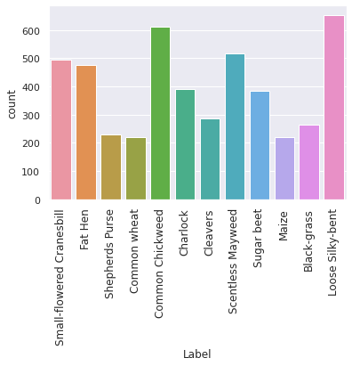

```python
# Plot countplot for weed labels
sns.countplot(labels_dataset['Label'])
plt.xticks(
    rotation=90,
    horizontalalignment='center',
    fontweight='normal',
    fontsize='large'
)
plt.show()
```

```python
# Create a test list for the images and labels
# There are many images so let's pick 5 samples ramdomly
lo = 0
hi = img_dataset.shape[0]
size = 4
test_list = [0]
tmp = random.sample(range(lo, hi), k=size)
print(tmp)
test_list.extend(tmp)
print(test_list)
```

```
[681, 2666, 2238, 1445]
[0, 681, 2666, 2238, 1445]
```

[output not shown]

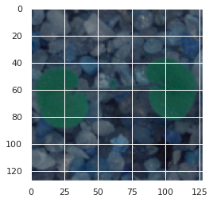

[output not shown]

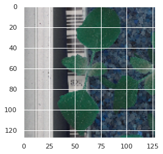

[output not shown]

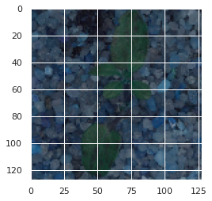

[output not shown]

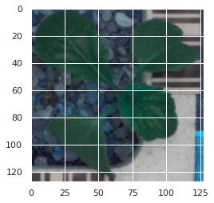

[output not shown]

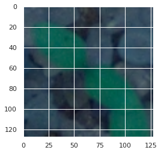

```python
# Let's print the image, labels  and plot the actual image from testlist
for i in test_list:
  print()
  print(img_dataset[i])
  print()
  print(labels_dataset.loc[i])
  print()
  plt.imshow(img_dataset[i])
  plt.show()
  print("======================================")
```

### `Insights:`

1. There are 4750 color images in the dataset and size of each image is 128x 128 Pixels.
2. There are 4750 labels. The datatype of the lable is "object"
3. There are 654 samples of Loose Silky-bent, followed by 611 samples of Common Chickweed 611
4. The least 221 samples for Maize and Common wheat each

# 2. Data Pre-processing

a. Normalization.

b. Gaussian Blurring.

c. Visualize data after pre-processing.

```python
# Convert the image dataset into a transformed dataset and apply the Gaussian blurring and some grayscale/color filter
trans_img_dataset = []

for img in img_dataset:

  # Apply the Gaussian blurring to smoothen the image and reduce the noice and details.
  gb_img = cv2.GaussianBlur(img, (5, 5), 0)

  # Convert image to grayscale. cv2.COLOR_BGR2GRAY, which converts colour image to grayscale.
  # NOTE: Applying grayscale filter doesn't help much so trying different filter
  # gray_img = cv2.cvtColor(gb_img, cv2.COLOR_BGR2GRAY)

  # from here: https://opencv-python-tutroals.readthedocs.io/en/latest/py_tutorials/py_imgproc/py_colorspaces/py_colorspaces.html
  # Convert BGR to HSV
  hsv_img = cv2.cvtColor(gb_img, cv2.COLOR_BGR2HSV)

  # Define range of green color in HSV
  lower_green = np.array([25,50,50])
  upper_green = np.array([50,255,255])

  # Apply threshold to the HSV image to get only green colors
  mask = cv2.inRange(hsv_img, lower_green, upper_green)

  # Apply Bitwise-AND mask on original image
  res_img = cv2.bitwise_and(gb_img, gb_img, mask=mask)

  trans_img_dataset.append(res_img)

trans_img_dataset = np.asarray(trans_img_dataset)
```

```python
# Normalize the image
trans_img_dataset = trans_img_dataset.astype('float32')/255.0
```

```
Original image at index 0
```

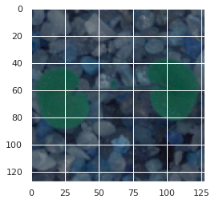

```
---------------------
Transformed image at the index 0
```

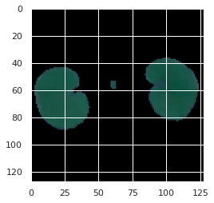

```
========================
Original image at index 681
```

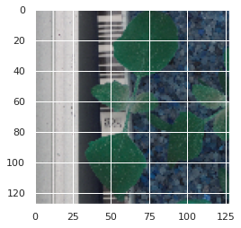

```
---------------------
Transformed image at the index 681
```

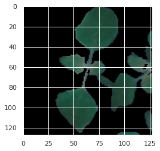

```
========================
Original image at index 2666
```

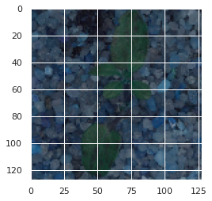

```
---------------------
Transformed image at the index 2666
```

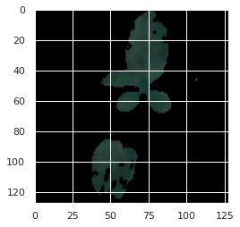

```
========================
Original image at index 2238
```

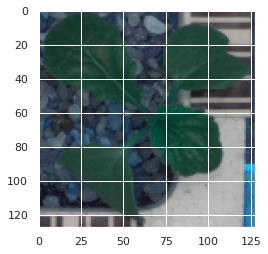

```
---------------------
Transformed image at the index 2238
```

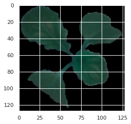

```
========================
Original image at index 1445
```

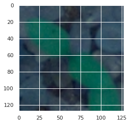

```
---------------------
Transformed image at the index 1445
```

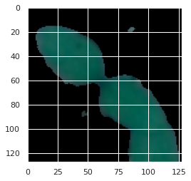

```python
# Compare the original and transformed images of the testlist
for i in test_list:
  print("Original image at index {}".format(i))
  plt.imshow(img_dataset[i])
  plt.show()
  print("---------------------")
  print("Transformed image at the index {}".format(i))
  plt.imshow(trans_img_dataset[i])
  plt.show()
  print()
  print("========================")
```

# 3. Make data compatible

a. Convert labels to one-hot-vectors.

b. Print the label for y_train[0].

c. Split the dataset into training, testing, and validation set.(Hint: First split images and labels into training and testing set with test_size = 0.3. Then further split test data into test and validation set with test_size = 0.5)

d. Check the shape of data, Reshape data into shapes compatible with Keras models if it’s not already. If it’s already in the compatible shape, then comment in the notebook that it’s already in compatible shape.

```python
# Convert the Labels into categorical variables
weed_labels = labels_dataset['Label'].unique()
print("The weeds are: \n {}".format(weed_labels))

le = preprocessing.LabelEncoder()
le.fit(weed_labels)

encoded_weed_labels = le.transform(labels_dataset['Label'])
# print(encoded_weed_labels)

y=to_categorical(encoded_weed_labels)
print("The target column y is: \n{}".format(y))
```

```
The weeds are:
 ['Small-flowered Cranesbill' 'Fat Hen' 'Shepherds Purse' 'Common wheat'
 'Common Chickweed' 'Charlock' 'Cleavers' 'Scentless Mayweed' 'Sugar beet'
 'Maize' 'Black-grass' 'Loose Silky-bent']
The target column y is:
[[0. 0. 0. ... 0. 1. 0.]
 [0. 0. 0. ... 0. 1. 0.]
 [0. 0. 0. ... 0. 1. 0.]
 ...
 [0. 0. 0. ... 0. 0. 0.]
 [0. 0. 0. ... 0. 0. 0.]
 [0. 0. 0. ... 0. 0. 0.]]
```

```python
# Check the shape of the y(labels) data
y.shape
```

```
(4750, 12)
```

```python
# Print the 1st target categorical variable y[0]
y[0]
```

```
array([0., 0., 0., 0., 0., 0., 0., 0., 0., 0., 1., 0.], dtype=float32)
```

```python
# Print y for the index of testlist
for i in test_list:
  print(" The target variable y[{}] = {}".format(i, y[i]))
```

```
 The target variable y[0] = [0. 0. 0. 0. 0. 0. 0. 0. 0. 0. 1. 0.]
 The target variable y[681] = [0. 0. 0. 0. 0. 1. 0. 0. 0. 0. 0. 0.]
 The target variable y[2666] = [0. 0. 1. 0. 0. 0. 0. 0. 0. 0. 0. 0.]
 The target variable y[2238] = [0. 1. 0. 0. 0. 0. 0. 0. 0. 0. 0. 0.]
 The target variable y[1445] = [0. 0. 0. 1. 0. 0. 0. 0. 0. 0. 0. 0.]
```

```python
# Split the data into training and test sets with test_size=0.3
X_train, X_test, y_train, y_test = train_test_split(trans_img_dataset, y,
                                                test_size=0.30, random_state=15,
                                                stratify=y)
```

```python
# Print the shape of splitted data
print("X_train shape: {}".format(X_train.shape))
print("X_test shape: {}".format(X_test.shape))
print("y_train shape: {}".format(y_train.shape))
print("y_test shape: {}".format(y_test.shape))
```

```
X_train shape: (3325, 128, 128, 3)
X_test shape: (1425, 128, 128, 3)
y_train shape: (3325, 12)
y_test shape: (1425, 12)
```

```python
# Further split the Test data into validation and test set with test_size=0.50
X_val, X_test, y_val, y_test = train_test_split(X_test, y_test,
                                                test_size=0.50, random_state=15,
                                                stratify=y_test)
```

```python
# Let's print the shape of splitted data
print("X_val shape: {}".format(X_val.shape))
print("X_test shape: {}".format(X_test.shape))
print("y_val shape: {}".format(y_val.shape))
print("y_test shape: {}".format(y_test.shape))
```

```
X_val shape: (712, 128, 128, 3)
X_test shape: (713, 128, 128, 3)
y_val shape: (712, 12)
y_test shape: (713, 12)
```

## `Insights:`

- As per instruction, The data has been splitted into training and test set with test_size=03. and then later the test data is splitted into validation and test set with the test_size=0.5
- Looking at the shape of the data, we see that data is correctly transformed and split in accordance to the instruction
- Looking at the image size of 128x128 is good for the modelling purpose so it doesn't requred to reduce the image size so I am NOT reduceing the size using reshape fuction. eg X_train = X_train.reshape(X_train.shape[0], 32, 32, 1)

# 4. Building CNN:

a. Define layers.

b. Set optimizer and loss function. (Use Adam optimizer and categorical crossentropy.)

```python
# To make more variation for the input, Let's alter the training data with small transformations
# from https://www.tensorflow.org/api_docs/python/tf/keras/preprocessing/image/ImageDataGenerator

datagen = ImageDataGenerator(
        rotation_range=180,  # randomly rotate images in the range 0 to 180
        zoom_range = 0.1, # Randomly zoom image
        width_shift_range=0.1,  # randomly shift images horizontally
        height_shift_range=0.1,  # randomly shift images vertically
        horizontal_flip=True,  # randomly flip images
        vertical_flip=True, # randomly flip images
        )

datagen.fit(X_train)
```

```python
# Create the model
model = Sequential()
model.add(layers.Conv2D(32, (3, 3), activation='relu', input_shape=(X_train.shape[1], X_train.shape[2], X_train.shape[3]))) # input shape = (128, 128, 3)
model.add(layers.MaxPooling2D((2, 2)))
model.add(layers.Conv2D(64, (3, 3), activation='relu'))
model.add(layers.MaxPooling2D((2, 2)))
model.add(layers.Conv2D(128, (3, 3), activation='relu'))
model.add(layers.MaxPooling2D((2, 2)))
model.add(layers.Conv2D(128, (3, 3), activation='relu'))
model.add(layers.MaxPooling2D((2, 2)))
model.add(layers.Flatten())
model.add(layers.Dense(64, activation='relu'))
model.add(layers.Dense(weed_labels.size, activation='softmax')) # We have total 12 output class

# Print the model summary
model.summary()
```

```
Model: "sequential"
_________________________________________________________________
Layer (type)                 Output Shape              Param #
=================================================================
conv2d (Conv2D)              (None, 126, 126, 32)      896
_________________________________________________________________
max_pooling2d (MaxPooling2D) (None, 63, 63, 32)        0
_________________________________________________________________
conv2d_1 (Conv2D)            (None, 61, 61, 64)        18496
_________________________________________________________________
max_pooling2d_1 (MaxPooling2 (None, 30, 30, 64)        0
_________________________________________________________________
conv2d_2 (Conv2D)            (None, 28, 28, 128)       73856
_________________________________________________________________
max_pooling2d_2 (MaxPooling2 (None, 14, 14, 128)       0
_________________________________________________________________
conv2d_3 (Conv2D)            (None, 12, 12, 128)       147584
_________________________________________________________________
max_pooling2d_3 (MaxPooling2 (None, 6, 6, 128)         0
_________________________________________________________________
flatten (Flatten)            (None, 4608)              0
_________________________________________________________________
dense (Dense)                (None, 64)                294976
_________________________________________________________________
dense_1 (Dense)              (None, 12)                780
=================================================================
Total params: 536,588
Trainable params: 536,588
Non-trainable params: 0
_________________________________________________________________
```

```python
# Apply the loss function and optimizer
model.compile(loss='categorical_crossentropy', metrics=['accuracy'], optimizer='adam')
```

# 5. Fit and evaluate model and print confusion matrix

```python
# Adding Early stopping callback to the fit function is going to stop the training,
# if the val_loss is not going to change even '0.09' for more than 10 continous epochs
# callback = tf.keras.callbacks.EarlyStopping(monitor='val_accuracy', patience=25, min_delta=0.09)
```

```python
# As we are dealing with large dataset which has high memory requirement, instead of using fit, let's use fit_generator
batch=X_train.shape[1]
epoch=int(batch/2)

#history = model.fit_generator(datagen.flow(X_train, y_train, batch_size=batch), epochs=epoch, validation_data=(X_val, y_val), verbose=2), callbacks=[callback])
history = model.fit_generator(datagen.flow(X_train, y_train, batch_size=batch), epochs=epoch, validation_data=(X_val, y_val), verbose=2)
```

```
26/26 - 14s - loss: 2.1939 - accuracy: 0.2445 - val_loss: 1.7600 - val_accuracy: 0.3933
26/26 - 12s - loss: 1.7849 - accuracy: 0.3717 - val_loss: 1.6439 - val_accuracy: 0.4185
26/26 - 12s - loss: 1.5981 - accuracy: 0.4445 - val_loss: 1.3892 - val_accuracy: 0.5042
26/26 - 12s - loss: 1.4028 - accuracy: 0.5125 - val_loss: 1.1709 - val_accuracy: 0.5927
26/26 - 12s - loss: 1.2530 - accuracy: 0.5711 - val_loss: 1.0358 - val_accuracy: 0.6615
26/26 - 12s - loss: 1.0887 - accuracy: 0.6352 - val_loss: 0.8829 - val_accuracy: 0.7219
26/26 - 12s - loss: 0.9913 - accuracy: 0.6602 - val_loss: 0.8150 - val_accuracy: 0.7542
26/26 - 12s - loss: 0.9394 - accuracy: 0.6899 - val_loss: 0.8131 - val_accuracy: 0.7388
26/26 - 13s - loss: 0.8881 - accuracy: 0.7080 - val_loss: 0.6968 - val_accuracy: 0.7823
26/26 - 13s - loss: 0.7682 - accuracy: 0.7504 - val_loss: 0.6000 - val_accuracy: 0.8104
26/26 - 13s - loss: 0.7592 - accuracy: 0.7486 - val_loss: 0.6168 - val_accuracy: 0.7949
26/26 - 12s - loss: 0.7180 - accuracy: 0.7684 - val_loss: 0.7987 - val_accuracy: 0.7374
26/26 - 12s - loss: 0.7444 - accuracy: 0.7594 - val_loss: 0.6270 - val_accuracy: 0.7907
26/26 - 13s - loss: 0.7307 - accuracy: 0.7570 - val_loss: 0.5575 - val_accuracy: 0.8244
26/26 - 12s - loss: 0.6606 - accuracy: 0.7835 - val_loss: 0.5718 - val_accuracy: 0.8034
26/26 - 12s - loss: 0.6104 - accuracy: 0.7958 - val_loss: 0.6345 - val_accuracy: 0.7992
26/26 - 12s - loss: 0.6394 - accuracy: 0.7898 - val_loss: 0.5445 - val_accuracy: 0.8090
26/26 - 12s - loss: 0.6259 - accuracy: 0.7877 - val_loss: 0.4613 - val_accuracy: 0.8371
26/26 - 12s - loss: 0.5800 - accuracy: 0.8054 - val_loss: 0.4438 - val_accuracy: 0.8427
26/26 - 12s - loss: 0.6021 - accuracy: 0.7937 - val_loss: 0.4386 - val_accuracy: 0.8567
26/26 - 12s - loss: 0.5586 - accuracy: 0.8090 - val_loss: 0.4510 - val_accuracy: 0.8553
26/26 - 12s - loss: 0.5662 - accuracy: 0.8135 - val_loss: 0.4336 - val_accuracy: 0.8399
26/26 - 12s - loss: 0.5400 - accuracy: 0.8229 - val_loss: 0.4451 - val_accuracy: 0.8581
26/26 - 12s - loss: 0.5343 - accuracy: 0.8183 - val_loss: 0.4693 - val_accuracy: 0.8427
26/26 - 12s - loss: 0.5061 - accuracy: 0.8253 - val_loss: 0.4502 - val_accuracy: 0.8371
26/26 - 12s - loss: 0.4982 - accuracy: 0.8292 - val_loss: 0.3967 - val_accuracy: 0.8596
26/26 - 12s - loss: 0.4899 - accuracy: 0.8313 - val_loss: 0.4724 - val_accuracy: 0.8427
26/26 - 12s - loss: 0.4843 - accuracy: 0.8343 - val_loss: 0.3864 - val_accuracy: 0.8694
26/26 - 12s - loss: 0.4673 - accuracy: 0.8442 - val_loss: 0.4180 - val_accuracy: 0.8581
26/26 - 12s - loss: 0.4444 - accuracy: 0.8457 - val_loss: 0.3625 - val_accuracy: 0.8736
26/26 - 12s - loss: 0.4302 - accuracy: 0.8478 - val_loss: 0.4694 - val_accuracy: 0.8525
26/26 - 12s - loss: 0.4514 - accuracy: 0.8445 - val_loss: 0.4024 - val_accuracy: 0.8553
26/26 - 12s - loss: 0.4277 - accuracy: 0.8439 - val_loss: 0.4044 - val_accuracy: 0.8652
26/26 - 12s - loss: 0.4058 - accuracy: 0.8611 - val_loss: 0.4040 - val_accuracy: 0.8581
26/26 - 12s - loss: 0.4095 - accuracy: 0.8505 - val_loss: 0.3286 - val_accuracy: 0.8792
26/26 - 12s - loss: 0.3961 - accuracy: 0.8617 - val_loss: 0.3757 - val_accuracy: 0.8708
26/26 - 12s - loss: 0.3846 - accuracy: 0.8653 - val_loss: 0.4372 - val_accuracy: 0.8638
26/26 - 12s - loss: 0.3796 - accuracy: 0.8689 - val_loss: 0.3613 - val_accuracy: 0.8876
26/26 - 12s - loss: 0.3941 - accuracy: 0.8635 - val_loss: 0.3996 - val_accuracy: 0.8736
26/26 - 12s - loss: 0.3824 - accuracy: 0.8647 - val_loss: 0.3664 - val_accuracy: 0.8750
```

[output cut: 9 more lines]

```
26/26 - 12s - loss: 0.3361 - accuracy: 0.8746 - val_loss: 0.3433 - val_accuracy: 0.8666
26/26 - 12s - loss: 0.3255 - accuracy: 0.8812 - val_loss: 0.3198 - val_accuracy: 0.8736
26/26 - 12s - loss: 0.3434 - accuracy: 0.8767 - val_loss: 0.3866 - val_accuracy: 0.8581
26/26 - 12s - loss: 0.3176 - accuracy: 0.8836 - val_loss: 0.3626 - val_accuracy: 0.8736
26/26 - 12s - loss: 0.2893 - accuracy: 0.8974 - val_loss: 0.2971 - val_accuracy: 0.8876
26/26 - 12s - loss: 0.2909 - accuracy: 0.8908 - val_loss: 0.4023 - val_accuracy: 0.8525
26/26 - 12s - loss: 0.2872 - accuracy: 0.8929 - val_loss: 0.3487 - val_accuracy: 0.8750
26/26 - 12s - loss: 0.2965 - accuracy: 0.8884 - val_loss: 0.3119 - val_accuracy: 0.8876
26/26 - 12s - loss: 0.2843 - accuracy: 0.8944 - val_loss: 0.3383 - val_accuracy: 0.8764
26/26 - 12s - loss: 0.3250 - accuracy: 0.8785 - val_loss: 0.2906 - val_accuracy: 0.8961
26/26 - 12s - loss: 0.3299 - accuracy: 0.8806 - val_loss: 0.2804 - val_accuracy: 0.8876
26/26 - 12s - loss: 0.2988 - accuracy: 0.8902 - val_loss: 0.3262 - val_accuracy: 0.8694
26/26 - 12s - loss: 0.2881 - accuracy: 0.8911 - val_loss: 0.3212 - val_accuracy: 0.8834
26/26 - 12s - loss: 0.3301 - accuracy: 0.8746 - val_loss: 0.4284 - val_accuracy: 0.8638
26/26 - 12s - loss: 0.2820 - accuracy: 0.8995 - val_loss: 0.2825 - val_accuracy: 0.8890
```

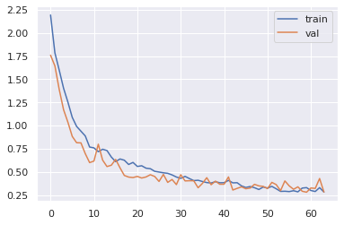

```python
# plot training loss history
plt.plot(history.history['loss'], label='train')
plt.plot(history.history['val_loss'], label='val')
plt.legend()
plt.show()
```

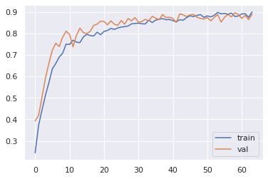

```python
# plot training accuracy history
plt.plot(history.history['accuracy'], label='train')
plt.plot(history.history['val_accuracy'], label='val')
plt.legend()
plt.show()
```

```python
# Evaluate the model on test data
model.evaluate(X_test, y_test)
```

```
[0.3026421070098877, 0.887798011302948]
```

```python
 # Predict the y on test input samples
y_pred = model.predict(X_test)
```

```python
print(y_test)
```

```
[[0. 0. 0. ... 1. 0. 0.]
 [0. 1. 0. ... 0. 0. 0.]
 [0. 0. 0. ... 0. 0. 0.]
 ...
 [0. 0. 0. ... 0. 0. 0.]
 [0. 0. 0. ... 0. 0. 0.]
 [0. 0. 0. ... 0. 1. 0.]]
```

```python
print(y_pred)
```

```
[[1.70584773e-08 1.91632216e-03 1.56768365e-04 ... 9.84664619e-01
  3.33975628e-03 2.24789474e-05]
 [2.38104425e-09 9.95031953e-01 1.11420319e-04 ... 4.56754025e-03
  4.77829599e-05 4.28591511e-06]
 [1.68779825e-05 1.61903575e-08 1.16463674e-07 ... 1.30187441e-03
  2.11613224e-06 2.33871586e-04]
 ...
 [5.07096887e-01 9.05672664e-07 8.54194695e-06 ... 1.36599461e-08
  9.38199810e-05 2.68001422e-05]
 [7.70372003e-02 1.29662496e-07 8.42416921e-06 ... 2.46171030e-08
  3.34066244e-05 4.46847537e-07]
 [5.55093360e-10 1.75908044e-05 5.59401769e-06 ... 1.69894658e-03
  9.97650206e-01 2.50601516e-07]]
```

```python
# Convert the y_test and y_predict
# from here: https://numpy.org/devdocs/reference/generated/numpy.argmax.html

# Return the column position with the max value
y_test_formatted = np.argmax(y_test, axis = 1)
print(y_test_formatted)
y_pred_formatted = np.argmax(y_pred, axis = 1)
print(y_pred_formatted)
```

```
[ 9  1  3  8 11 10  3 11  6 10  8  5  8  8  1  6  2  1  5  3 11  8  0  3
  9  6  0  2  2  6 10  6  1  3  4 10  8  3 11  1  6  3  4  9  8 11  1 11
  2  5 11  3  8  0  5 10  2  6  2  3  3  8  8  3  4  5  3  2  9  3  7  8
  5  0  7 11  3  4  2  8  6  6  6  0  6 11 10  9  7  3  9  7  9  5  6  8
  6  5  4  3  3  6 10  7  3 11  3  4 11  3 10  7  6 11 10  5  6  3  0  9
  5  6  8  9  1  7  6  6  8 10  5  5 11  3 10  8  4 10  6 10  2  8  5 10
  5  5  8  2  6  2  6  7  0  8  9 10  4  0  6 10 11  9  0 10  7  1  1  3
  5  3 11  7  6  4  3  0  2  6  3 11 11  0 10 11 10  6 10  3  6 10  5  4
  8  2  7  8  8  3  6  4  5  9  0  3  4  5  8  5  1  1  5  1 11  8  0  3
  8 10  7 11  6  6  3  7  8 10  8 10  3  1  1  3  8  0  1  2 10  5  3  1
  1  9  3 10  2 11  0 10  8 10  1  1 10 11  3 10  4  8  8  0  1  8  0  5
  8  6  5 10  9 10  3  7  2  8  6  4  1  3  2  3  5 10  2  5  6  5  8  3
  5  5  3  3  7  8  3  2  6  3  8  1  1  6 10  5  5 11  3 10 10  5  5  2
  8  1  4  6  3  8  5 11  3  7  9 10  1  6  1  8  3  8 11  4 11 10 10  6
  7  0 11  8 11  3  6  5  4 11  1  7  4  1  1  6  6  9  8  1  2 11  9  5
```

[output cut: 45 more lines]

```python
print(accuracy_score(y_test_formatted, y_pred_formatted))
```

```
0.8877980364656382
```

```python
# Print the classification report
print(classification_report(y_test_formatted, y_pred_formatted))
```

```
              precision    recall  f1-score   support

           0       0.50      0.18      0.26        39
           1       0.96      0.95      0.96        58
           2       0.93      0.93      0.93        43
           3       0.95      0.97      0.96        92
           4       0.80      0.85      0.82        33
           5       0.94      0.94      0.94        72
           6       0.74      0.92      0.82        98
           7       1.00      0.85      0.92        33
           8       0.91      0.91      0.91        78
           9       0.78      0.94      0.85        34
          10       1.00      0.95      0.97        75
          11       0.93      0.93      0.93        58

    accuracy                           0.89       713
   macro avg       0.87      0.86      0.86       713
weighted avg       0.88      0.89      0.88       713
```

[figure not shown]

```python
# Print the confustion matrix
cm = confusion_matrix(y_test_formatted, y_pred_formatted)
plt.figure(figsize=(15,12))
sns.heatmap(cm, annot=True, fmt='d')
plt.xlabel('Predicted')
plt.ylabel('True')
ticks = np.arange(len(weed_labels))
plt.xticks(ticks, weed_labels, rotation=90)
plt.yticks(ticks, weed_labels, rotation=0)

plt.title('Confusion Matrix for Plant Seedling Image Classification')
```

# 6. Visualize predictions for x_test[2], x_test[3], x_test[33], x_test[36], x_test[59]

```python
# Convert the numbers to the actual human friendly labels for predicted weed samples
y_pred_formatted_df = le.inverse_transform(y_pred_formatted)
# print(y_pred_formatted_df)
```

```python
# Convert the numbers to the actual human friendly labels for test weed samples
y_test_formatted_df = le.inverse_transform(y_test_formatted)
# print(y_pred_formatted_df)
```

```
The original test weed sample at index 2 is Common Chickweed
The predicted weed name at index 2 is Common Chickweed
```

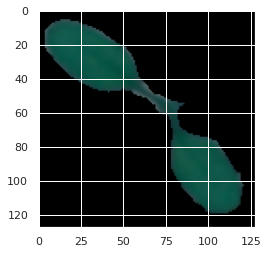

```
================================================================

The original test weed sample at index 3 is Scentless Mayweed
The predicted weed name at index 3 is Scentless Mayweed
```

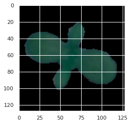

```
================================================================

The original test weed sample at index 33 is Common Chickweed
The predicted weed name at index 33 is Common Chickweed
```

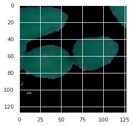

```
================================================================

The original test weed sample at index 36 is Scentless Mayweed
The predicted weed name at index 36 is Scentless Mayweed
```

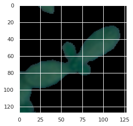

```
================================================================

The original test weed sample at index 59 is Common Chickweed
The predicted weed name at index 59 is Common Chickweed
```

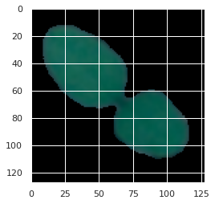

```python
#  Test for the different test inputs x_test[2], x_test[3], x_test[33], x_test[36], x_test[59]
test_inputs = [2, 3, 33, 36, 59]
for i in test_inputs:
  print()
  print("The original test weed sample at index {} is {}".format(i, y_test_formatted_df[i]))
  print("The predicted weed name at index {} is {}".format(i, y_pred_formatted_df[i]))
  plt.imshow(X_test[i])
  plt.show()
  print("================================================================")
```